# Miami-Dade 311 Requests and Property Crime Analysis

Zara Gonzalez, Johnny Nguyen, Elston Miller, Nicholas Alex, Wesley Huang

April 26, 2026

# Project Goal

The goal of this project is to analyze the relationship between citizen service requests and property crime patterns in Miami-Dade County from 2017 to 2019.

We aim to answer:

1. How do 311 service requests change over time?
2. What types of service requests are most common?
3. How do property crime trends change over the same time period?
4. Is there a relationship between 311 complaints and property crime trends?

# Load Required Packages

```r
library(tidyverse)
library(lubridate)
library(readxl)
library(tidytext)
library(stringr)
library(ggplot2)
library(scales)
```

# Data Sources

This project uses two datasets:

1. Miami-Dade 311 Service Requests from 2017, 2018, and 2019.
2. Florida Department of Law Enforcement property crime data from 2017, 2018, and 2019.

The 311 dataset represents citizen-reported non-emergency service requests.  
The property crime dataset represents official reported property crime incidents.

# Load 311 Service Request Data

```r
Miami1 <- read.csv("data/311_Service_Requests_-_Miami-Dade_County_-_2017.csv")
Miami2 <- read.csv("data/311_Service_Requests_-_Miami-Dade_County_-_2018.csv")
Miami3 <- read.csv("data/311_Service_Requests_-_Miami-Dade_County_-_2019.csv")
```

# Clean 311 Data

```r
# Replace missing issue descriptions with blank text
Miami1$issue_description[is.na(Miami1$issue_description)] <- ""
Miami2$issue_description[is.na(Miami2$issue_description)] <- ""
Miami3$issue_description[is.na(Miami3$issue_description)] <- ""

# Convert date columns to date-time format
Miami1$ticket_created_date_time <- ymd_hms(Miami1$ticket_created_date_time, quiet = TRUE)
Miami2$ticket_created_date_time <- ymd_hms(Miami2$ticket_created_date_time, quiet = TRUE)
Miami3$ticket_created_date_time <- ymd_hms(Miami3$ticket_created_date_time, quiet = TRUE)

Miami1$ticket__last_update_date_time <- ymd_hms(Miami1$ticket__last_update_date_time, quiet = TRUE)
Miami2$ticket__last_update_date_time <- ymd_hms(Miami2$ticket__last_update_date_time, quiet = TRUE)
Miami3$ticket__last_update_date_time <- ymd_hms(Miami3$ticket__last_update_date_time, quiet = TRUE)

Miami1$ticket_closed_date_time <- ymd_hms(Miami1$ticket_closed_date_time, quiet = TRUE)
Miami2$ticket_closed_date_time <- ymd_hms(Miami2$ticket_closed_date_time, quiet = TRUE)
Miami3$ticket_closed_date_time <- ymd_hms(Miami3$ticket_closed_date_time, quiet = TRUE)

# Create year variable
Miami1$year <- year(Miami1$ticket_created_date_time)
Miami2$year <- year(Miami2$ticket_created_date_time)
Miami3$year <- year(Miami3$ticket_created_date_time)

# Combine all 311 datasets
combined_311 <- bind_rows(Miami1, Miami2, Miami3)

# Keep analysis focused on 2017-2019
combined_311 <- combined_311 %>%
  filter(year %in% c(2017, 2018, 2019))
```

# Cleaned 311 Dataset Preview

```r
glimpse(combined_311)
```

```
## Rows: 966,645
## Columns: 27
## $ ticket_id                     <chr> "17-10000001", "17-10000002", "17-100000…
## $ issue_type                    <chr> "ASU POLICE ASSISTANCE", "ANIMALS - CODE…
## $ issue_description             <chr> "", "", "", "", "", "", "", "", "", "", …
## $ case_owner                    <chr> "Enforcement_Section-3-36", "Regulatory_…
## $ case_owner_description        <chr> "Enforcement Section", "Regulatory and E…
## $ street_address                <chr> "7800 NW 22ND AVE", "11549 NE 13TH AVE",…
## $ city                          <chr> "Miami_Dade_County", "Miami_Dade_County"…
## $ state                         <chr> "Florida", "Florida", "Florida", "Florid…
## $ zip_code                      <int> 33147, 33161, 33161, 33196, 33187, 33034…
## $ neighborhood_district         <chr> "District 2", "District 3", "District 3"…
## $ created_year_month            <int> 20171, 20171, 20171, 20171, 20171, 20171…
## $ ticket_created_date_time      <dttm> 2017-01-01 07:36:16, 2017-01-01 08:43:3…
## $ ticket__last_update_date_time <dttm> 2017-01-01 08:49:39, 2017-01-06 19:27:1…
## $ ticket_closed_date_time       <dttm> 2017-01-01 08:49:39, 2017-01-06 19:27:0…
## $ ticket_status                 <chr> "CLOSED", "CLOSED", "CLOSED", "CLOSED", …
## $ location_city                 <chr> "Miami_Dade_County", "Miami_Dade_County"…
## $ sr_xcoordinate                <dbl> 908215.1, 928496.8, 928413.2, 842926.1, …
## $ sr_ycoordinate                <dbl> 550325.1, 563684.5, 563601.2, 490610.3, …
## $ latitude                      <dbl> 25.84565, 25.88206, 25.88183, 25.68226, …
## $ longitude                     <dbl> -80.23363, -80.17171, -80.17196, -80.432…
## $ method_received               <chr> "PHONE", "ANDROID", "ANDROID", "WEB", "A…
## $ sr_priority                   <chr> "URGENT", "STANDARD", "STANDARD", "STAND…
## $ goal_days                     <dbl> 180, 120, 90, 90, 90, 180, 180, 90, 180,…
## $ actual_completed_days         <int> 0, 5, 5, 4, 5, 0, 0, 2, 0, 0, 0, 2, 0, 0…
## $ ticket_year                   <int> 2017, 2017, 2017, 2017, 2017, 2017, 2017…
## $ ObjectId                      <int> 1, 2, 3, 4, 5, 6, 7, 8, 9, 10, 11, 12, 1…
## $ year                          <dbl> 2017, 2017, 2017, 2017, 2017, 2017, 2017…
```

```r
head(combined_311[, c("year", "issue_type", "issue_description", "ticket_created_date_time")])
```

```
##   year                   issue_type issue_description ticket_created_date_time
## 1 2017        ASU POLICE ASSISTANCE                        2017-01-01 07:36:16
## 2 2017    ANIMALS - CODE VIOLATIONS                        2017-01-01 08:43:33
## 3 2017 ABANDONED PROPERTY / VEHICLE                        2017-01-01 08:47:24
## 4 2017         ILLEGAL DUMPING - WM                        2017-01-01 12:43:46
## 5 2017         ILLEGAL DUMPING - WM                        2017-01-01 15:53:17
## 6 2017        ASU POLICE ASSISTANCE                        2017-01-01 16:19:35
```

# 311 Summary Tables

```r
issue_counts <- combined_311 %>%
  count(issue_type, sort = TRUE)

issue_by_year <- combined_311 %>%
  count(year, issue_type, sort = TRUE)

requests_total <- combined_311 %>%
  group_by(year) %>%
  summarise(total_requests = n())

head(issue_counts, 10)
```

```
##                     issue_type      n
## 1          BULKY TRASH REQUEST 266282
## 2     GREEN WASTE CART REQUEST 153571
## 3   RECYCLING BLUE CART ISSUES  45500
## 4  MOSQUITO INSPECTION REQUEST  39211
## 5         ILLEGAL DUMPING - WM  37637
## 6            GARBAGE COMPLAINT  36568
## 7                      POTHOLE  30155
## 8           PET ACCOUNT UPDATE  29899
## 9  JUNK AND TRASH / OVERGROWTH  22146
## 10          STRAY DOG-AT-LARGE  18827
```

```r
requests_total
```

```
## # A tibble: 3 × 2
##    year total_requests
##   <dbl>          <int>
## 1  2017         322432
## 2  2018         325879
## 3  2019         318334
```

# Load and Clean Property Crime Data

```r
# Load crime data
crime_2017 <- read_excel("data/PROPERTY_17.xlsx", skip = 2)
crime_2018 <- read_excel("data/Property-Crime-County-Type-2018.xlsx", skip = 2)
crime_2019 <- read_excel("data/Property-Crime-County-Type-2019.xlsx", skip = 2)

# Extract Miami-Dade and add year
miami_2017 <- crime_2017 %>%
  filter(County == "Miami-Dade") %>%
  mutate(year = 2017)

miami_2018 <- crime_2018 %>%
  filter(County == "Miami-Dade") %>%
  mutate(year = 2018)

miami_2019 <- crime_2019 %>%
  filter(County == "Miami-Dade") %>%
  mutate(year = 2019)

# Clean columns
clean_crime <- function(df) {
  df %>%
    select(
      year,
      Burglary,
      Larceny,
      `Motor Vehicle Theft`,
      `Total Property Crime`
    )
}

crime_combined <- bind_rows(
  clean_crime(miami_2017),
  clean_crime(miami_2018),
  clean_crime(miami_2019)
)
```

# Merged Dataset

```r
# Merge by year
final_merged <- left_join(crime_combined, requests_total, by = "year")

final_merged
```

```
## # A tibble: 3 × 6
##    year Burglary Larceny `Motor Vehicle Theft` `Total Property Crime`
##   <dbl>    <dbl>   <dbl>                 <dbl>                  <dbl>
## 1  2017    11628   72384                  8702                  92714
## 2  2018     9178   69295                  8336                  86809
## 3  2019     7936   69952                  7655                  85543
## # ℹ 1 more variable: total_requests <int>
```

# Exploratory Analysis: Most Common 311 Complaints

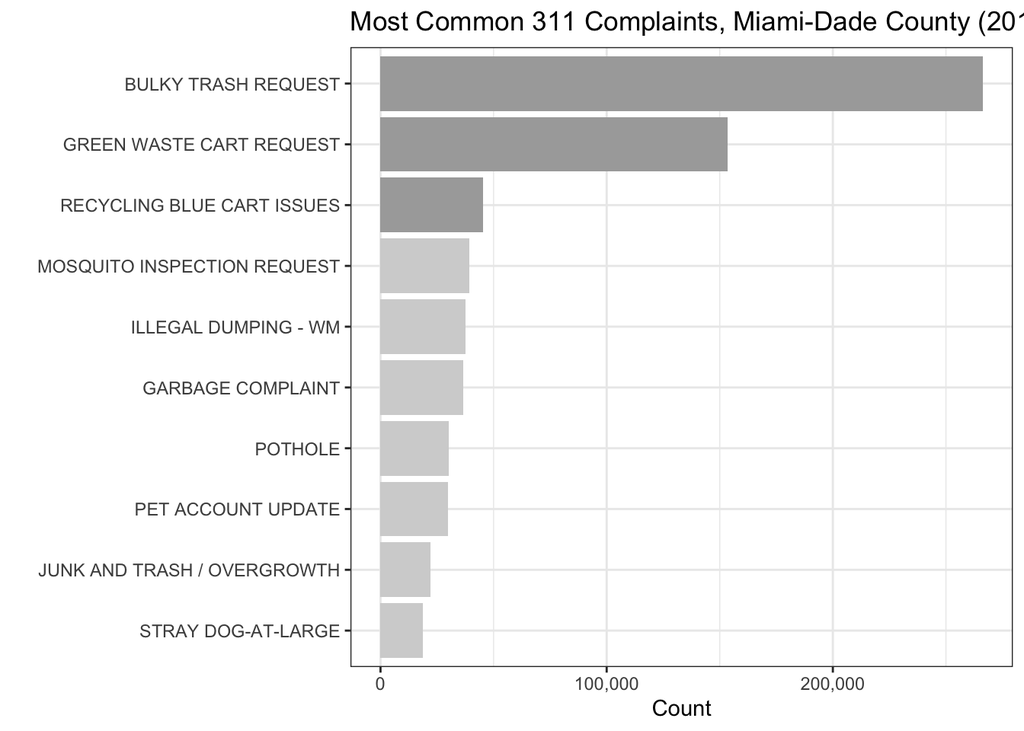

```r
plot_top_complaints <- issue_counts %>%
  arrange(desc(n)) %>%
  slice_head(n = 10)

top3 <- plot_top_complaints %>%
  arrange(desc(n)) %>%
  slice_head(n = 3) %>%
  pull(issue_type)

plot_top_complaints <- plot_top_complaints %>%
  mutate(label = ifelse(issue_type %in% top3, "top3", "other"))

topComplaints <- ggplot(plot_top_complaints, aes(x = n, y = reorder(issue_type, n), fill = label)) +
  geom_col() +
  scale_fill_manual(values = c("top3" = "darkgrey", "other" = "lightgrey")) +
  scale_x_continuous(labels = comma) +
  labs(
    title = "Most Common 311 Complaints, Miami-Dade County (2017-2019)",
    x = "Count",
    y = ""
  ) +
  theme_bw() +
  theme(legend.position = "none")

topComplaints
```

**Interpretation:**  
The most common 311 requests are mostly related to sanitation and public service issues, such as trash, waste, and maintenance requests. This suggests that 311 data reflects daily quality-of-life concerns reported by residents.

# 311 Requests Over Time

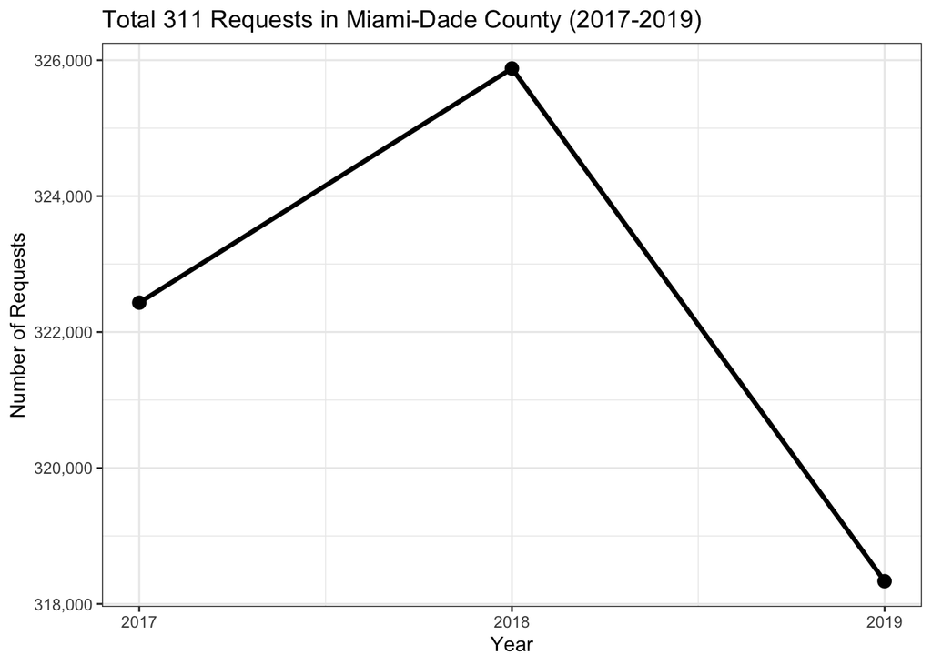

```r
plot_requests_total <- requests_total

requestsTrend <- ggplot(plot_requests_total, aes(x = year, y = total_requests)) +
  geom_line(linewidth = 1.2) +
  geom_point(size = 3) +
  scale_x_continuous(breaks = c(2017, 2018, 2019)) +
  scale_y_continuous(labels = comma) +
  labs(
    title = "Total 311 Requests in Miami-Dade County (2017-2019)",
    x = "Year",
    y = "Number of Requests"
  ) +
  theme_bw()

requestsTrend
```

**Interpretation:**  
311 requests increased from 2017 to 2018, then declined slightly in 2019. Overall, service request volume remained relatively stable across the three-year period.

# Property Crime Trends

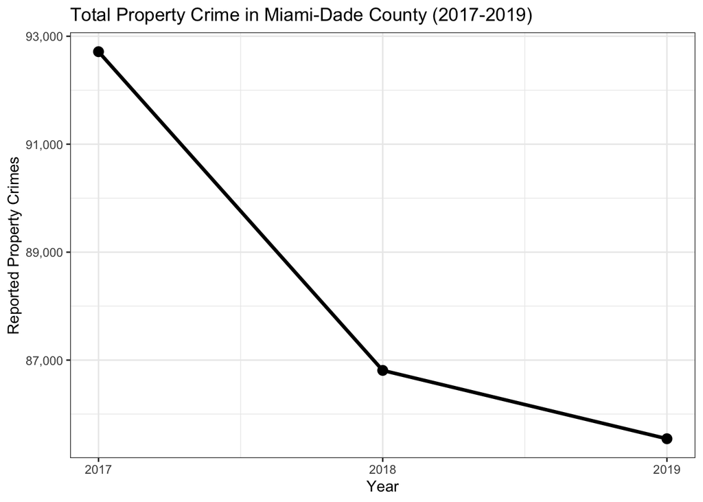

```r
plot_property_crime <- final_merged

propertyCrimeTrend <- ggplot(plot_property_crime, aes(x = year, y = `Total Property Crime`)) +
  geom_line(linewidth = 1.2) +
  geom_point(size = 3) +
  scale_x_continuous(breaks = c(2017, 2018, 2019)) +
  scale_y_continuous(labels = comma) +
  labs(
    title = "Total Property Crime in Miami-Dade County (2017-2019)",
    x = "Year",
    y = "Reported Property Crimes"
  ) +
  theme_bw()

propertyCrimeTrend
```

**Interpretation:**  
Property crime declined from 2017 to 2019. This trend allows comparison with 311 requests to determine whether citizen complaints move similarly to crime patterns.

# Comparison: 311 Requests vs Property Crime

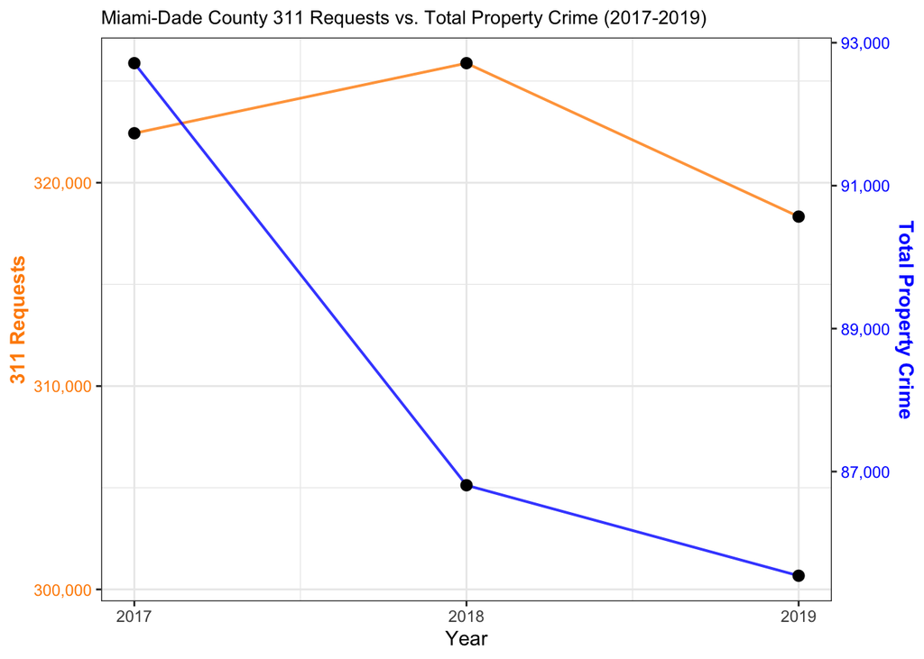

```r
plot_dual_axis <- final_merged

ratio <- max(plot_dual_axis$total_requests) / max(plot_dual_axis$`Total Property Crime`)

dualAxis <- ggplot(plot_dual_axis, aes(x = year)) +
  geom_line(
    aes(y = total_requests),
    colour = "darkorange",
    linewidth = 0.7,
    alpha = 0.8
  ) +
  geom_line(
    aes(y = `Total Property Crime` * ratio),
    colour = "blue",
    linewidth = 0.7,
    alpha = 0.8
  ) +
  geom_point(aes(y = total_requests), size = 2.5) +
  geom_point(aes(y = `Total Property Crime` * ratio), size = 2.5) +
  scale_y_continuous(
    name = "311 Requests",
    labels = comma,
    sec.axis = sec_axis(
      ~ . / ratio,
      name = "Total Property Crime",
      labels = comma
    )
  ) +
  scale_x_continuous(breaks = c(2017, 2018, 2019)) +
  labs(
    title = "Miami-Dade County 311 Requests vs. Total Property Crime (2017-2019)",
    x = "Year"
  ) +
  theme_bw() +
  theme(
    axis.title.y.left = element_text(color = "darkorange", face = "bold"),
    axis.text.y.left = element_text(color = "darkorange"),
    axis.title.y.right = element_text(color = "blue", face = "bold"),
    axis.text.y.right = element_text(color = "blue"),
    plot.title = element_text(size = 10.3)
  )

dualAxis
```

**Interpretation:**  
This chart compares the direction of change between 311 requests and property crime. While both datasets show some decline by 2019, the trends are not identical. This suggests that 311 complaints do not directly measure crime but may still reflect broader community conditions.

# Text Mining Preparation

```r
issue_data <- combined_311 %>%
  select(issue_type, year) %>%
  filter(!is.na(issue_type)) %>%
  mutate(
    issue_type = tolower(issue_type),
    issue_type = str_replace_all(issue_type, "[^a-z\\s]", "")
  )

issue_words <- issue_data %>%
  unnest_tokens(word, issue_type) %>%
  anti_join(stop_words, by = "word")
```

# Text Mining: Word Frequency Analysis

```r
# Prepare department description text
dept_data <- combined_311 %>%
  select(case_owner_description) %>%
  filter(!is.na(case_owner_description)) %>%
  mutate(
    case_owner_description = tolower(case_owner_description),
    case_owner_description = str_replace_all(case_owner_description, "[^a-z\\s]", "")
  )

dept_words <- dept_data %>%
  unnest_tokens(word, case_owner_description) %>%
  anti_join(stop_words, by = "word")
```

# Citizen Issue Word Frequency

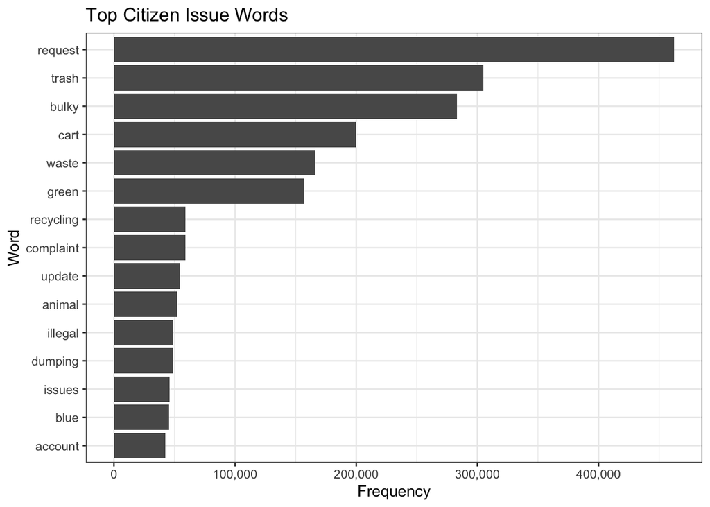

```r
plot_issue_words <- issue_words %>%
  count(word, sort = TRUE) %>%
  slice_head(n = 15)

issueWordPlot <- ggplot(plot_issue_words, aes(x = reorder(word, n), y = n)) +
  geom_col() +
  coord_flip() +
  scale_y_continuous(labels = comma) +
  labs(
    title = "Top Citizen Issue Words",
    x = "Word",
    y = "Frequency"
  ) +
  theme_bw()

issueWordPlot
```

**Interpretation:**  
The most frequent citizen issue words are related to requests, trash, bulky waste, carts, and recycling. This shows that most 311 complaints are focused on public services and quality-of-life concerns rather than direct crime issues.

# Department Description Word Frequency

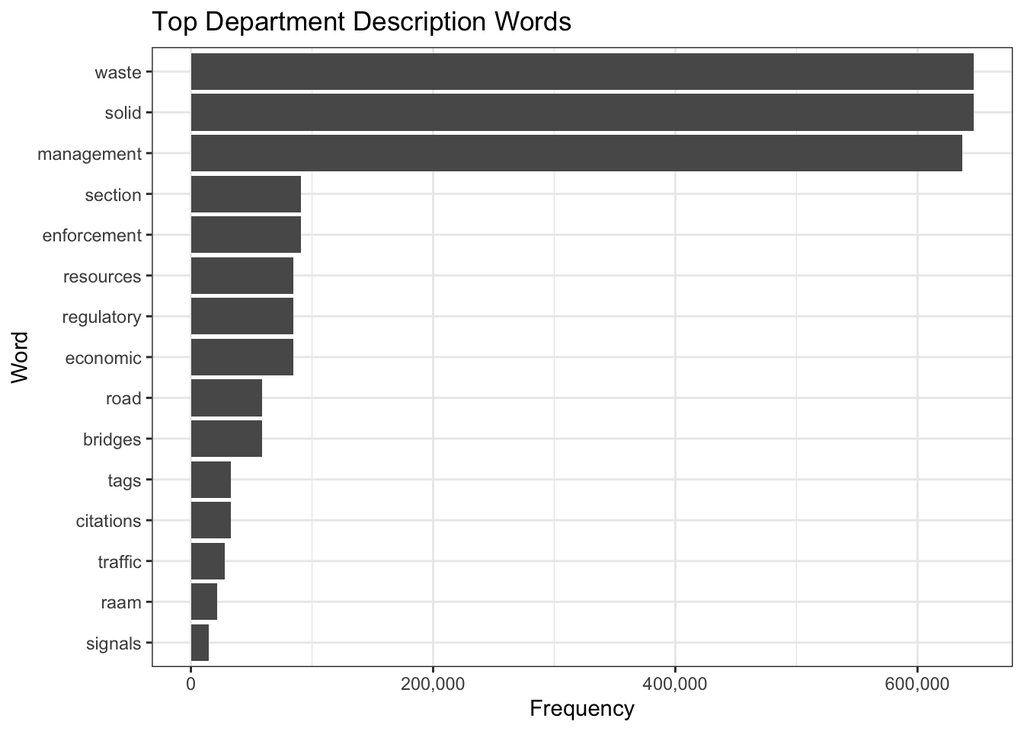

```r
plot_dept_words <- dept_words %>%
  count(word, sort = TRUE) %>%
  slice_head(n = 15)

deptWordPlot <- ggplot(plot_dept_words, aes(x = reorder(word, n), y = n)) +
  geom_col() +
  coord_flip() +
  scale_y_continuous(labels = comma) +
  labs(
    title = "Top Department Description Words",
    x = "Word",
    y = "Frequency"
  ) +
  theme_bw()

deptWordPlot
```

**Interpretation:**  
The department description words are mostly related to waste, solid management, enforcement, roads, bridges, and traffic. This suggests that departments classify many 311 requests as service, infrastructure, and public works issues.

# Citizen Issue vs Department Description Word Frequency

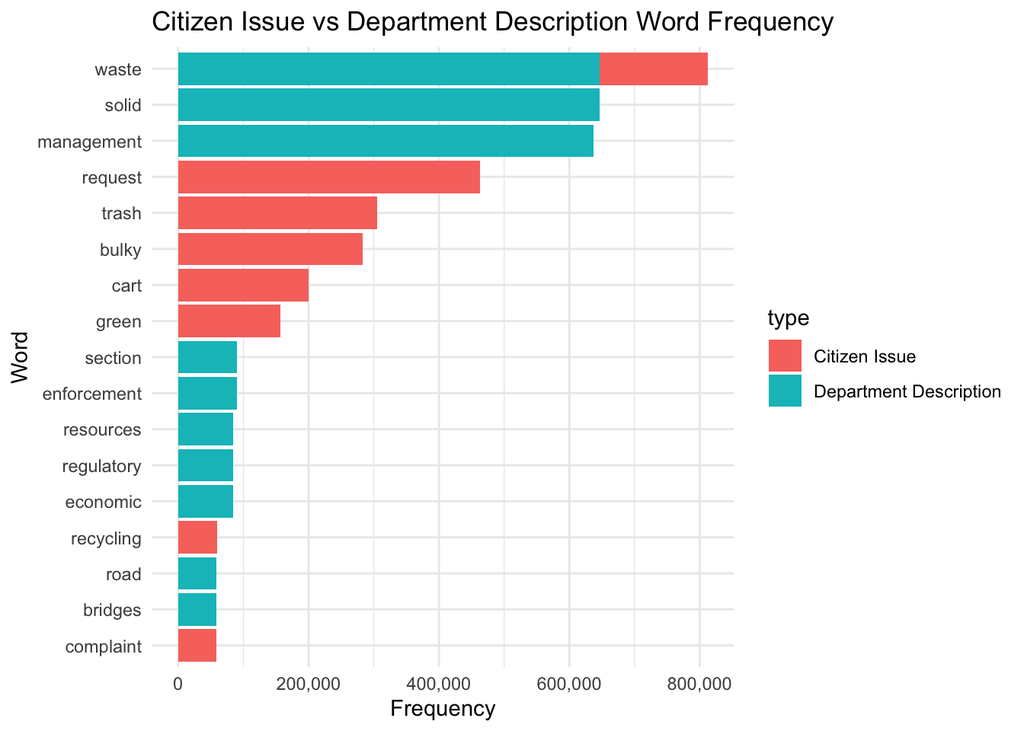

```r
plot_combined_words <- bind_rows(
  plot_issue_words %>% mutate(type = "Citizen Issue"),
  plot_dept_words %>% mutate(type = "Department Description")
) %>%
  group_by(word) %>%
  mutate(total_frequency = sum(n)) %>%
  ungroup() %>%
  arrange(desc(total_frequency)) %>%
  slice_head(n = 18)

combinedWordPlot <- ggplot(plot_combined_words, aes(
  x = reorder(word, total_frequency),
  y = n,
  fill = type
)) +
  geom_col() +
  coord_flip() +
  scale_y_continuous(labels = comma) +
  labs(
    title = "Citizen Issue vs Department Description Word Frequency",
    x = "Word",
    y = "Frequency",
    fill = "type"
  ) +
  theme_minimal()

combinedWordPlot
```

**Interpretation:**  
This comparison shows that citizens and departments describe issues differently, but both emphasize service-related problems. Citizen words focus more on visible complaints like trash and bulky waste, while department words focus more on administrative categories such as waste management and infrastructure.

# TF-IDF Analysis by Year

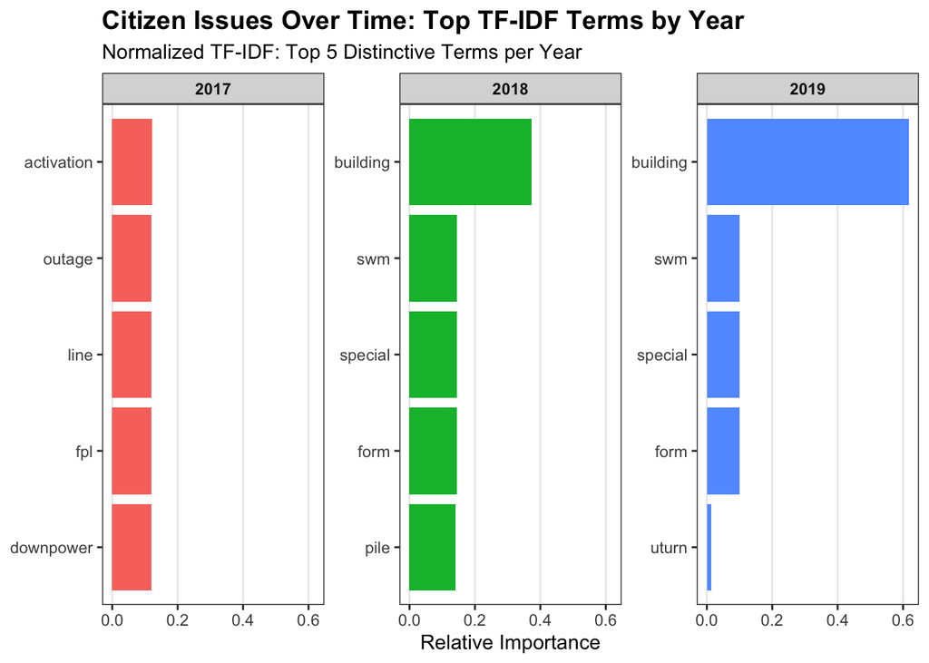

```r
plot_issue_tfidf <- issue_words %>%
  count(year, word, name = "n") %>%
  bind_tf_idf(word, year, n) %>%
  group_by(year) %>%
  mutate(tfidf_norm = tf_idf / sum(tf_idf)) %>%
  ungroup()

plot_top_words <- plot_issue_tfidf %>%
  group_by(year) %>%
  slice_max(tfidf_norm, n = 5, with_ties = FALSE) %>%
  ungroup()

tfidfPlot <- ggplot(plot_top_words, aes(
  x = reorder_within(word, tfidf_norm, year),
  y = tfidf_norm,
  fill = factor(year)
)) +
  geom_col(show.legend = FALSE) +
  coord_flip() +
  facet_wrap(~ year, scales = "free_y") +
  scale_x_reordered() +
  labs(
    title = "Citizen Issues Over Time: Top TF-IDF Terms by Year",
    subtitle = "Normalized TF-IDF: Top 5 Distinctive Terms per Year",
    x = NULL,
    y = "Relative Importance"
  ) +
  theme_bw() +
  theme(
    plot.title = element_text(face = "bold", size = 14),
    plot.subtitle = element_text(size = 11),
    strip.text = element_text(face = "bold"),
    panel.grid.major.y = element_blank(),
    panel.grid.minor = element_blank(),
    legend.position = "none"
  )

tfidfPlot
```

**Interpretation:**  
TF-IDF identifies words that are especially distinctive within each year. This helps show how citizen complaint themes shifted over time rather than only showing the most common words overall.

# Key Findings

1. 311 requests were mostly related to public service and quality-of-life issues.
2. Property crime declined from 2017 to 2019.
3. 311 complaints and property crime did not move in exactly the same pattern.
4. Text mining showed that complaint themes varied by year.
5. 311 data reflects public concerns but should not be treated as a direct measure of crime.

# Practical Implications

These findings can help local governments understand the difference between resident concerns and official crime trends. 311 data is useful for service planning and resource allocation, while crime data is better suited for public safety analysis. Using both datasets together provides a more complete view of community conditions.

# Save processed output files